# MOOD BRAIN & DEVELOPMENT UNIT

##### General anxiety symptoms

SCARED (Self-Report for Anxiety Related Emotional Disorders): 41 items rated 0-2, clinical cutoff = 25.

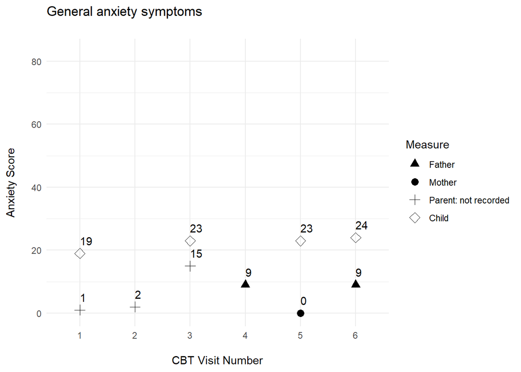

| Visit Date | Visit Number | Child SCARED | Father SCARED | Mother SCARED | Parent SCARED: not recorded |
| --- | --- | --- | --- | --- | --- |
| 2019-07-17 | 1 | 19 |  |  | 1 |
| 2019-07-24 | 2 |  |  |  | 2 |
| 2019-07-31 | 3 | 23 |  |  | 15 |
| 2019-08-07 | 4 |  | 9 |  |  |
| 2019-08-28 | 5 | 23 |  | 0 |  |
| 2019-09-04 | 6 | 24 | 9 |  |  |

##### Anhedonia symptoms

SHAPS (Snaith-Hamilton Pleasure Scale): 14 items rated 0-3, higher scores reflecting less pleasure.

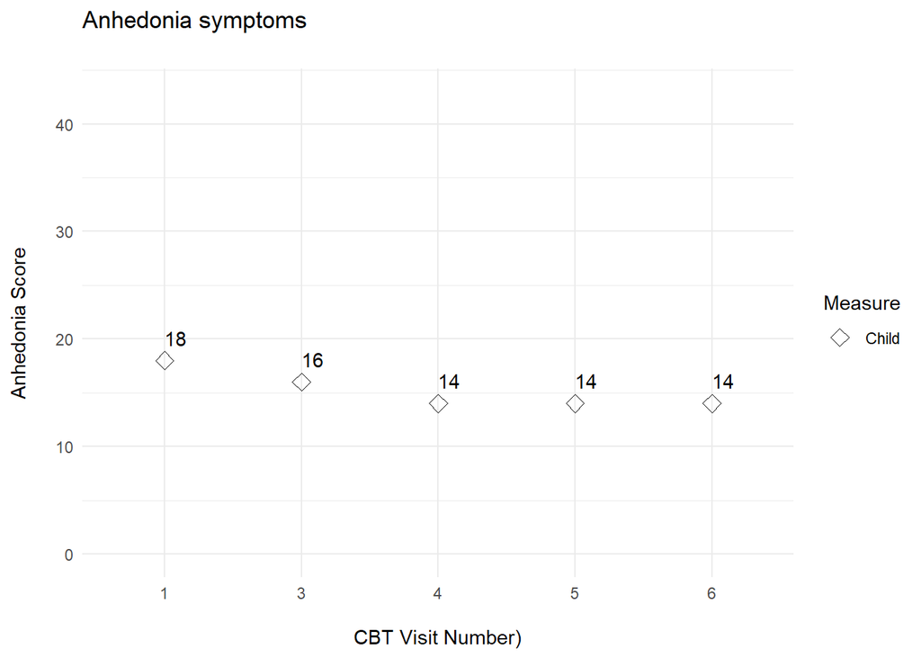

| Visit Date | Visit Number | Child SHAPS |
| --- | --- | --- |
| 2019-07-17 | 1 | 18 |
| 2019-07-31 | 3 | 16 |
| 2019-08-07 | 4 | 14 |
| 2019-08-28 | 5 | 14 |
| 2019-09-04 | 6 | 14 |

##### Irritability symptoms

ARI (Affective Reactivity Index): 7 items rated 0-2, clinical cutoff = 2.

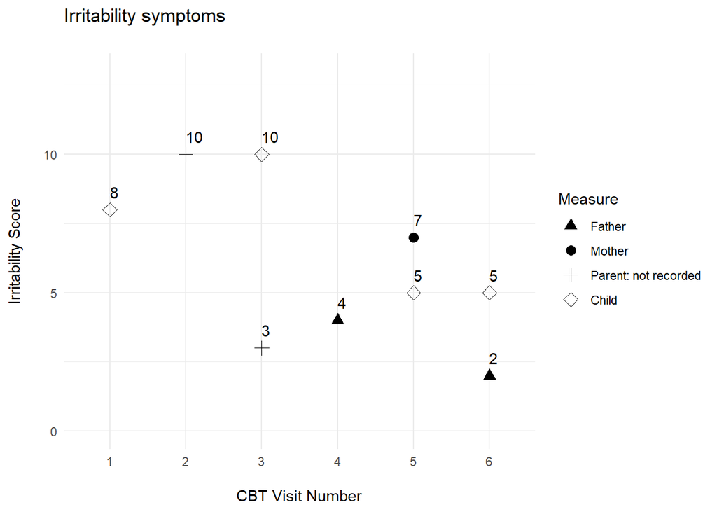

| Visit Date | Visit Number | Child ARI | Father ARI | Mother ARI | Parent ARI: not recorded |
| --- | --- | --- | --- | --- | --- |
| 2019-07-17 | 1 | 8 |  |  |  |
| 2019-07-24 | 2 |  |  |  | 10 |
| 2019-07-31 | 3 | 10 |  |  | 3 |
| 2019-08-07 | 4 |  | 4 |  |  |
| 2019-08-28 | 5 | 5 |  | 7 |  |
| 2019-09-04 | 6 | 5 | 2 |  |  |

##### Social anxiety symptoms

LSAS (Liebowitz Social Anxiety Scale): 24 items rated 0-3, clinical cutoff = 30.

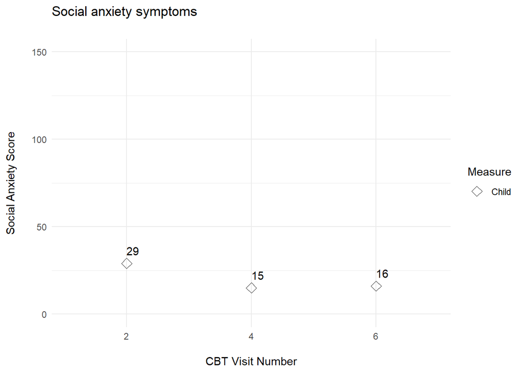

| Visit Date | Visit Number | Child LSAS |
| --- | --- | --- |
| 2019-07-24 | 2 | 29 |
| 2019-08-07 | 4 | 15 |
| 2019-09-04 | 6 | 16 |

We plan to send regular updates for you to monitor Averi-lyn’s progress in our program.

Please contact us at the number below with any questions.

Respectfully Yours,

Kathryn DeLonga, Psy.D,  
Licensed Clinical Psychologist, Director of Psychological Treatment,  
Mood Brain & Development Unit,  
National Institute of Mental Health,  
National Institutes of Health,  
Bethesda, MD  
Tel: 301-827-1168